# Parameters and training compute in notable AI models

09 November 2026

## Research question

Do notable AI models with more parameters also require more training compute, and has this relationship changed across the three eras of AI development?

## Data set introduction

```r
compute_raw <- read.csv(
  "Data/raw/training-computation-vs-dataset-size-in-notable-ai-systems.csv",
  check.names = FALSE
)
parameters_raw <- read.csv(
  "Data/raw/parameters-in-notable-artificial-intelligence-systems.csv",
  check.names = FALSE
)

ai_joined <- inner_join(compute_raw, parameters_raw, by = c("Entity", "Day"))

ai_models <- ai_joined |>
  mutate(
    year = as.numeric(substr(Day, 1, 4)),
    era = case_when(
      year < 2010 ~ "Pre-deep learning",
      year <= 2015 ~ "Deep learning",
      TRUE ~ "Large-scale"
    ),
    era = factor(era, levels = c("Pre-deep learning", "Deep learning", "Large-scale"))
  ) |>
  select(
    parameters = `Number of parameters`,
    training_compute = `Training computation (petaFLOP)`,
    dataset_size = `Training dataset size`,
    year,
    era
  ) |>
  filter(!is.na(parameters), !is.na(training_compute), !is.na(dataset_size))

c(
  compute_file = nrow(compute_raw),
  parameters_file = nrow(parameters_raw),
  joined = nrow(ai_joined),
  complete = nrow(ai_models)
)
```

```
##    compute_file parameters_file          joined        complete
##             760             720             605             409
```

```r
write.csv(ai_models, "Data/merged.csv", row.names = FALSE)
```

The data covers notable AI models and comes from two Our World in Data files by Epoch AI (2026), with major processing by Our World in Data: [training compute and dataset size](https://ourworldindata.org/grapher/training-computation-vs-dataset-size-in-notable-ai-systems) and [number of parameters](https://ourworldindata.org/grapher/parameters-in-notable-artificial-intelligence-systems). The code above joins the two files by model name and date and keeps only models with no missing values, so each row is one model.

`parameters` is the number of weights in a model, and `training_compute` is the compute used to train it, in petaFLOP (one petaFLOP is $10^{15}$ calculations). `dataset_size` is the amount of training data, and its unit (images, words or game steps) depends on the type of model. `year` is the year the model was published, and `era` groups each model into one of three periods from Sevilla et al. (2022): pre-deep learning (before 2010), deep learning (2010–2015) and large-scale (2016 onwards).

```r
variable_types <- data.frame(
  variable = names(ai_models),
  type = sapply(ai_models, class),
  row.names = NULL
)

kable(variable_types, caption = "Variables in the analysis table")
```

Variables in the analysis table

| variable | type |
| --- | --- |
| parameters | numeric |
| training_compute | numeric |
| dataset_size | numeric |
| year | numeric |
| era | factor |

## Data set description

The data set has 5 variables and 409 observations, and each observation is one AI model.

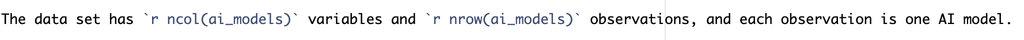

```r
include_graphics("Image/inline-r-code.png")
```

```r
str(head(ai_models, 2))
```

```
## 'data.frame':    2 obs. of  5 variables:
##  $ parameters      : num  1.85e+08 1.51e+08
##  $ training_compute: num  666 592
##  $ dataset_size    : num  2.00e+06 1.03e+08
##  $ year            : num  2018 2018
##  $ era             : Factor w/ 3 levels "Pre-deep learning",..: 3 3
```

## Data summary

```r
era_summary <- ai_models |>
  select(era, parameters, training_compute) |>
  group_by(era) |>
  summarise(
    median_parameters = median(parameters),
    mean_parameters = mean(parameters),
    median_compute = median(training_compute),
    mean_compute = mean(training_compute)
  ) |>
  head(10)

kable(
  era_summary,
  caption = "Median and mean parameters and training compute (petaFLOP) by era",
  format.args = list(digits = 3)
)
```

Median and mean parameters and training compute (petaFLOP) by era

| era | median_parameters | mean_parameters | median_compute | mean_compute |
| --- | --- | --- | --- | --- |
| Pre-deep learning | 1.86e+04 | 5.84e+09 | 1.96e-04 | 4.08e+01 |
| Deep learning | 2.36e+07 | 1.66e+09 | 5.40e+01 | 2.24e+04 |
| Large-scale | 1.84e+09 | 1.14e+11 | 9.00e+06 | 1.33e+09 |

Median parameters and median training compute both **rise** in each era, from about 18,600 parameters and 0.0002 petaFLOP before 2010 to about 1.8 billion parameters and 9 million petaFLOP from 2016. Each mean is far above its median because a few very large models pull it up, so the median better describes a typical model.

## Visualisation

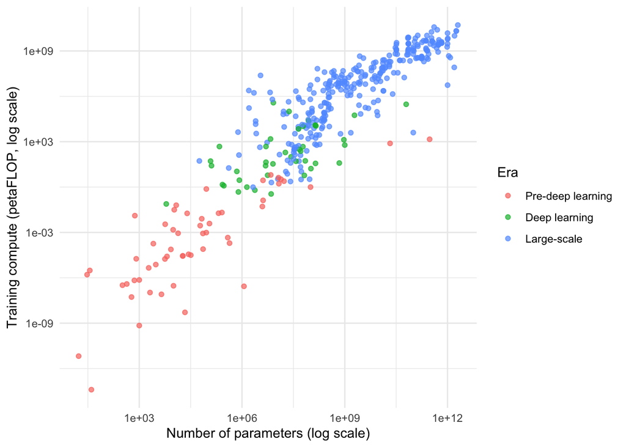

Parameters and training compute of notable AI models, coloured by era (both axes on a log scale)

```r
ggplot(ai_models, aes(x = parameters, y = training_compute, colour = era)) +
  geom_point(alpha = 0.7) +
  scale_x_log10() +
  scale_y_log10() +
  labs(
    x = "Number of parameters (log scale)",
    y = "Training compute (petaFLOP, log scale)",
    colour = "Era"
  ) +
  theme_minimal()
```

- *Models with more parameters used more training compute, so the points form a clear upward band in all three eras.*
- *Large-scale models with the same number of parameters, they often used more compute than older models.*

### Training compute over time

The figure below shows training compute by year, to check how fast compute grew in each era. Before 2010 the points rise slowly, but from 2010 they climb much more steeply, and most large-scale models from 2016 sit above all earlier models. This matches Sevilla et al. (2022), who found that training compute doubled about every 20 months before 2010 and about every 6 months after.

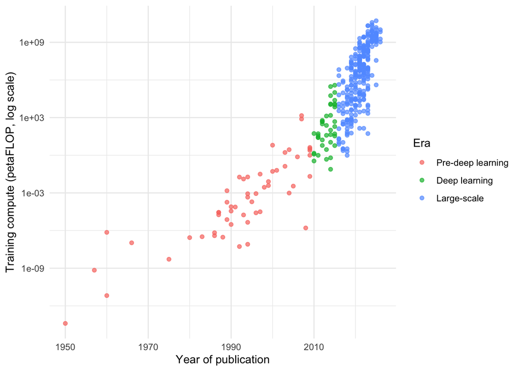

Training compute of notable AI models by year, coloured by era (log scale)

```r
ggplot(ai_models, aes(x = year, y = training_compute, colour = era)) +
  geom_point(alpha = 0.7) +
  scale_y_log10() +
  labs(
    x = "Year of publication",
    y = "Training compute (petaFLOP, log scale)",
    colour = "Era"
  ) +
  theme_minimal()
```

### Large models with little compute

The table below checks whether some models had many parameters but needed fewer compute. Within each era, a model is large if its parameters are above the era median, and it used little compute if its compute is below the era median. Most large models also used a lot of compute, which supports the main answer. However, in every era some large models used little compute: 19% before 2010, 25% in 2010–2015 and 12% from 2016. One possible reason may be sparse designs such as mixture-of-experts models, which add parameters while each input uses only a small part of them (Fedus et al., 2022). Median dataset size is shown for context only, because its unit differs by type of model.

```r
large_low_compute <- ai_models |>
  group_by(era) |>
  mutate(
    large = parameters > median(parameters),
    low_compute = training_compute < median(training_compute)
  ) |>
  summarise(
    models = n(),
    large_models = sum(large),
    large_low_compute = sum(large & low_compute),
    share_percent = round(100 * large_low_compute / large_models),
    median_dataset_size = median(dataset_size)
  )

kable(
  large_low_compute,
  caption = "Large models (above-median parameters) that used below-median training compute, by era",
  format.args = list(digits = 3)
)
```

Large models (above-median parameters) that used below-median training compute, by era

| era | models | large_models | large_low_compute | share_percent | median_dataset_size |
| --- | --- | --- | --- | --- | --- |
| Pre-deep learning | 55 | 27 | 5 | 19 | 2.43e+04 |
| Deep learning | 41 | 20 | 5 | 25 | 1.30e+06 |
| Large-scale | 313 | 156 | 19 | 12 | 3.83e+10 |

## Conclusions

The data from Epoch AI (2026) shows that notable AI models with more parameters also needed more training compute. Median parameters and compute rise together in all three eras from Sevilla et al. (2022), and the first figure shows a clear upward band. The link has also changed over time: compute grew much faster from 2010, and large-scale models often used more compute than older models with the same number of parameters. The link holds for most models but not all, because in every era 12% to 25% of large models used little compute, possibly because of sparse designs (Fedus et al., 2022). One limitation is that dataset size cannot be compared across models: an image model counts images and a language model counts words, so the same number can mean very different amounts of data, and the data has no domain column to separate them.

## References

Epoch AI (2026) – with major processing by Our World in Data. “Parameter, Compute and Data Trends in Machine Learning.” Retrieved 24 October 2026 from Our World in Data, https://ourworldindata.org/grapher/training-computation-vs-dataset-size-in-notable-ai-systems and https://ourworldindata.org/grapher/parameters-in-notable-artificial-intelligence-systems.

Sevilla, J., Heim, L., Ho, A., Besiroglu, T., Hobbhahn, M., and Villalobos, P. (2022). Compute Trends Across Three Eras of Machine Learning. arXiv:2202.05924. https://arxiv.org/abs/2202.05924

Fedus, W., Zoph, B., and Shazeer, N. (2022). Switch Transformers: Scaling to Trillion Parameter Models with Simple and Efficient Sparsity. *Journal of Machine Learning Research*, 23(120), 1–39. https://jmlr.org/papers/v23/21-0998.html

## AI acknowledgement

I used the AI assistant to test R results, format code style, and refine the wording.